# Bike Sharing - an example of linear regression

Piotr Patrzylas

“Readme.txt” file found on the: http://archive.ics.uci.edu/ml/datasets/Bike+Sharing+Dataset

========================================= Background =========================================

Bike sharing systems are new generation of traditional bike rentals where whole process from membership, rental and return back has become automatic. Through these systems, user is able to easily rent a bike from a particular position and return back at another position. Currently, there are about over 500 bike-sharing programs around the world which is composed of over 500 thousands bicycles. Today, there exists great interest in these systems due to their important role in traffic, environmental and health issues.

Apart from interesting real world applications of bike sharing systems, the characteristics of data being generated by these systems make them attractive for the research. Opposed to other transport services such as bus or subway, the duration of travel, departure and arrival position is explicitly recorded in these systems. This feature turns bike sharing system into a virtual sensor network that can be used for sensing mobility in the city. Hence, it is expected that most of important events in the city could be detected via monitoring these data.

========================================= Data Set =========================================  
Bike-sharing rental process is highly correlated to the environmental and seasonal settings. For instance, weather conditions, precipitation, day of week, season, hour of the day, etc. can affect the rental behaviors. The core data set is related to  
the two-year historical log corresponding to years 2011 and 2012 from Capital Bikeshare system, Washington D.C., USA which is publicly available in http://capitalbikeshare.com/system-data. We aggregated the data on two hourly and daily basis and then extracted and added the corresponding weather and seasonal information. Weather information are extracted from http://www.freemeteo.com.

========================================= Associated tasks =========================================

```
- Regression:
    Predication of bike rental count hourly or daily based on the environmental and seasonal settings.
```

End of “readme.txt”.

========================================= 1. Data analysis and visualization =========================================  
a) Daily data set:  
- instant: record index  
- dteday : date  
- season : season (1:winter, 2:spring, 3:summer, 4:fall)  
- yr : year (0: 2011, 1:2012)  
- mnth : month ( 1 to 12)  
- holiday : weather day is holiday or not (extracted from [Web Link])  
- weekday : day of the week  
- workingday : if day is neither weekend nor holiday is 1, otherwise is 0.  
+ weathersit :  
- 1: Clear, Few clouds, Partly cloudy, Partly cloudy  
- 2: Mist + Cloudy, Mist + Broken clouds, Mist + Few clouds, Mist  
- 3: Light Snow, Light Rain + Thunderstorm + Scattered clouds, Light Rain + Scattered clouds  
- 4: Heavy Rain + Ice Pallets + Thunderstorm + Mist, Snow + Fog  
- temp : Normalized temperature in Celsius. The values are derived via (t-t_min)/(t_max-t_min), t_min=-8, t_max=+39 (only in hourly scale)  
- atemp: Normalized feeling temperature in Celsius. The values are derived via (t-t_min)/(t_max-t_min), t_min=-16, t_max=+50 (only in hourly scale)  
- hum: Normalized humidity. The values are divided to 100 (max)  
- windspeed: Normalized wind speed. The values are divided to 67 (max)  
- casual: count of casual users  
- registered: count of registered users  
- cnt: count of total rental bikes including both casual and registered

Data pre-processing

```r
Bike1 = read.csv("day.csv")
Bike1$season <- as.factor(Bike1$season)
Bike1$dteday <- as.POSIXct(Bike1$dteday)
Bike1$yr <- as.factor(Bike1$yr)
Bike1$mnth <- as.factor(Bike1$mnth)
Bike1$holiday <- as.factor(Bike1$holiday)
Bike1$weekday <- as.factor(Bike1$weekday)
Bike1$workingday <- as.factor(Bike1$workingday)
Bike1$weathersit <- as.factor(Bike1$weathersit)
```

Data structure and summary

```
##     instant          dteday                    season  yr
##  Min.   :  1.0   Min.   :2011-01-01 00:00:00   1:181   0:365
##  1st Qu.:183.5   1st Qu.:2011-07-02 12:00:00   2:184   1:366
##  Median :366.0   Median :2012-01-01 00:00:00   3:188
##  Mean   :366.0   Mean   :2011-12-31 23:24:22   4:178
##  3rd Qu.:548.5   3rd Qu.:2012-07-01 12:00:00
##  Max.   :731.0   Max.   :2012-12-31 00:00:00
##
##       mnth     holiday weekday workingday weathersit      temp
##  1      : 62   0:710   0:105   0:231      1:463      Min.   :0.05913
##  3      : 62   1: 21   1:105   1:500      2:247      1st Qu.:0.33708
##  5      : 62           2:104              3: 21      Median :0.49833
##  7      : 62           3:104                         Mean   :0.49538
##  8      : 62           4:104                         3rd Qu.:0.65542
##  10     : 62           5:104                         Max.   :0.86167
##  (Other):359           6:105
##      atemp              hum           windspeed           casual
##  Min.   :0.07907   Min.   :0.0000   Min.   :0.02239   Min.   :   2.0
##  1st Qu.:0.33784   1st Qu.:0.5200   1st Qu.:0.13495   1st Qu.: 315.5
##  Median :0.48673   Median :0.6267   Median :0.18097   Median : 713.0
##  Mean   :0.47435   Mean   :0.6279   Mean   :0.19049   Mean   : 848.2
##  3rd Qu.:0.60860   3rd Qu.:0.7302   3rd Qu.:0.23321   3rd Qu.:1096.0
##  Max.   :0.84090   Max.   :0.9725   Max.   :0.50746   Max.   :3410.0
##
##    registered        cnt
##  Min.   :  20   Min.   :  22
##  1st Qu.:2497   1st Qu.:3152
##  Median :3662   Median :4548
##  Mean   :3656   Mean   :4504
##  3rd Qu.:4776   3rd Qu.:5956
##  Max.   :6946   Max.   :8714
##
```

```
## 'data.frame':    731 obs. of  16 variables:
##  $ instant   : int  1 2 3 4 5 6 7 8 9 10 ...
##  $ dteday    : POSIXct, format: "2011-01-01" "2011-01-02" ...
##  $ season    : Factor w/ 4 levels "1","2","3","4": 1 1 1 1 1 1 1 1 1 1 ...
##  $ yr        : Factor w/ 2 levels "0","1": 1 1 1 1 1 1 1 1 1 1 ...
##  $ mnth      : Factor w/ 12 levels "1","2","3","4",..: 1 1 1 1 1 1 1 1 1 1 ...
##  $ holiday   : Factor w/ 2 levels "0","1": 1 1 1 1 1 1 1 1 1 1 ...
##  $ weekday   : Factor w/ 7 levels "0","1","2","3",..: 7 1 2 3 4 5 6 7 1 2 ...
##  $ workingday: Factor w/ 2 levels "0","1": 1 1 2 2 2 2 2 1 1 2 ...
##  $ weathersit: Factor w/ 3 levels "1","2","3": 2 2 1 1 1 1 2 2 1 1 ...
##  $ temp      : num  0.344 0.363 0.196 0.2 0.227 ...
##  $ atemp     : num  0.364 0.354 0.189 0.212 0.229 ...
##  $ hum       : num  0.806 0.696 0.437 0.59 0.437 ...
##  $ windspeed : num  0.16 0.249 0.248 0.16 0.187 ...
##  $ casual    : int  331 131 120 108 82 88 148 68 54 41 ...
##  $ registered: int  654 670 1229 1454 1518 1518 1362 891 768 1280 ...
##  $ cnt       : int  985 801 1349 1562 1600 1606 1510 959 822 1321 ...
```

```
## [1] "NA elements"
```

```
##    instant     dteday     season         yr       mnth    holiday
##          0          0          0          0          0          0
##    weekday workingday weathersit       temp      atemp        hum
##          0          0          0          0          0          0
##  windspeed     casual registered        cnt
##          0          0          0          0
```

```
## [1] "Null elements"
```

```
##    instant     dteday     season         yr       mnth    holiday
##          0          0          0          0          0          0
##    weekday workingday weathersit       temp      atemp        hum
##          0          0          0          0          0          0
##  windspeed     casual registered        cnt
##          0          0          0          0
```

Correlation between response (total count) and some of the predictors

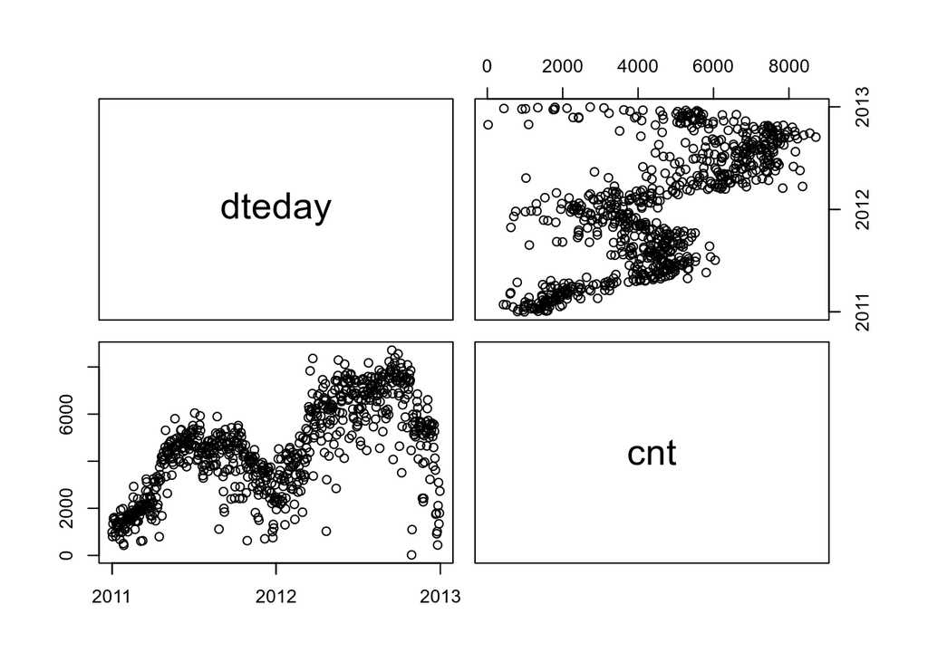

```
## [1] "In general there is more rentals in the 2nd year. Rentals seems to follow a trend described below."
```